# Analisando Commits no Git

## Introdução

Neste checkpoint irei avaliar a popularidade, utilizando a quantidade de usuários do github, associados aos dias de semana, diferenciando entre os dias de semana e os finais de semana.

Irei avaliar os arquivos com extensão **js**(JavaScript) e **py**(Python), no qual a partir da amostra que temos cedida pelo github faremos uma inferência sobre a população utilizando um estimador, neste caso optei por utilizar a média.

## Desenvolvimento

Neste momento irei mostrar as informações sobre os arquivos .py e .js contidos na amostra, tomando como base os gráficos de fim de semana e final de semana.

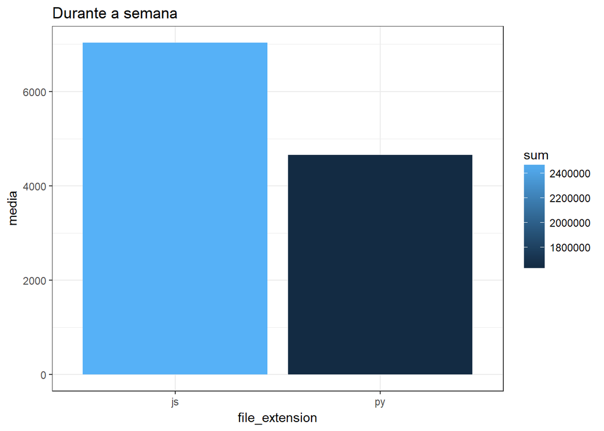

```r
semana <- dados %>%
  filter(day %in% c("segunda-feira", "terça-feira",  "quarta-feira",  "quinta-feira",  "sexta-feira"))

fim.semana <- dados %>%
  filter(day %in% c("sábado", "domingo"))

semana.py <- semana %>%
  filter(file_extension %in% "py")

semana.js <- semana %>%
  filter(file_extension %in% "js")

fim.semana.py <- fim.semana %>%
  filter(file_extension %in% "py")

fim.semana.js <- fim.semana %>%
  filter(file_extension %in% "js")

dados.semana <- semana %>%
  group_by(file_extension) %>%
  summarise(media = mean(users), mediana = median(users), sum = sum(users), numobser = n())

dados.final.semana <- fim.semana %>%
  group_by(file_extension) %>%
  summarise(media = mean(users), mediana = median(users), sum = sum(users), numobser = n())

ggplot(data = dados.semana, aes(x = file_extension, y = media, fill = sum)) +
  geom_bar(stat = "identity") +
  ggtitle("Durante a semana")
```

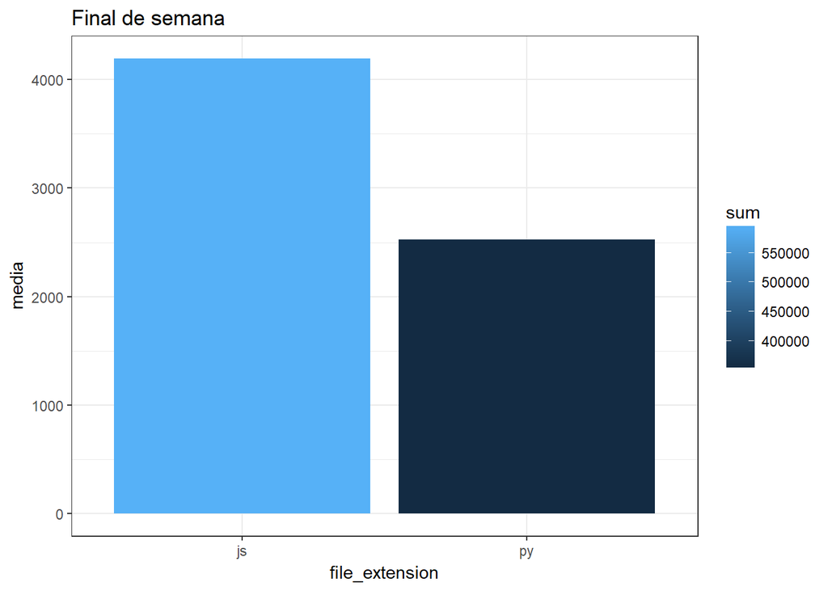

```r
ggplot(data = dados.final.semana, aes(x = file_extension, y = media, fill = sum)) +
  geom_bar(stat = "identity") +
  ggtitle("Final de semana")
```

```r
glimpse(dados.semana)
```

```
## Observations: 2
## Variables: 5
## $ file_extension <chr> "js", "py"
## $ media          <dbl> 7036.206, 4650.655
## $ mediana        <dbl> 7190, 4729
## $ sum            <int> 2497853, 1646332
## $ numobser       <int> 355, 354
```

```r
glimpse(dados.final.semana)
```

```
## Observations: 2
## Variables: 5
## $ file_extension <chr> "js", "py"
## $ media          <dbl> 4196.063, 2524.873
## $ mediana        <dbl> 4305, 2586
## $ sum            <int> 595841, 358532
## $ numobser       <int> 142, 142
```

Porém, nosso questionamento é sobre a população, tendo em vista que temos apenas uma amostra é necessário que façamos uma inferência para que a partir dela obtivamos dados da população. Para inferir sobre os dados iremos utilizar a técnica bootstrap, que consiste em uma reamostragem realizadas b vezes e em cada vez é calculada a estatística e que nos interessa (no nosso caso a **média**) para cada uma das amostras.

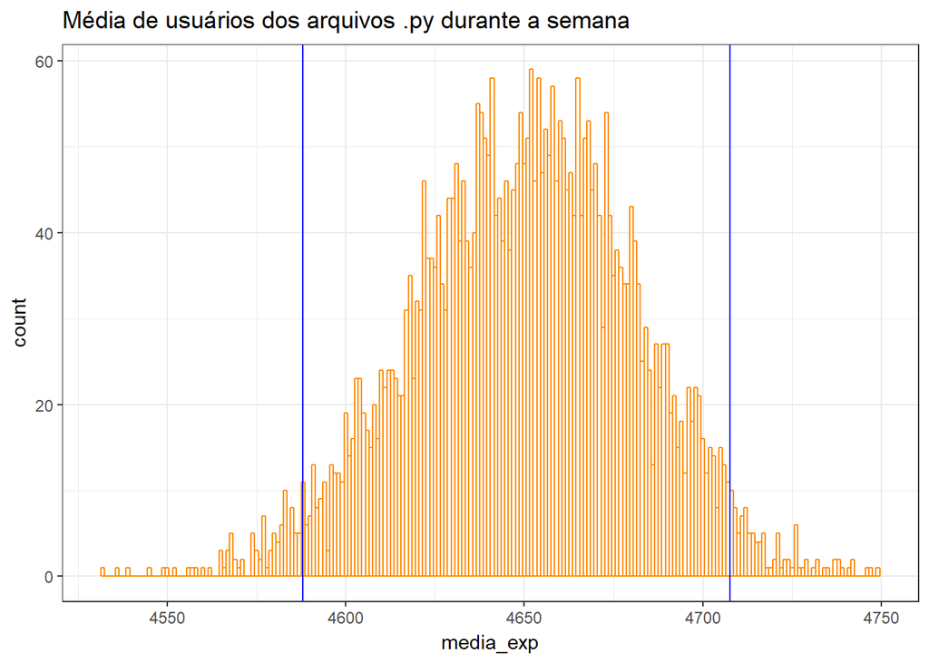

```r
repeticoes = 4000 # pelo menos 2000, mas mais não faz mal.

exp_com_bootstrap <- function(x){
  boot_x <- sample(x, size = NROW(x), replace = TRUE) # aqui é o bootstrap
  return(mean(boot_x))
}

#Python
# Agora o input das reamostragens é a amostra!
experimentos.semana.py = data_frame(i = 1:repeticoes) %>%
  rowwise() %>%
  mutate(media_exp = exp_com_bootstrap(semana.py$users)) # <- Aqui!

experimentos.fim.semana.py = data_frame(i = 1:repeticoes) %>%
  rowwise() %>%
  mutate(media_exp = exp_com_bootstrap(fim.semana.py$users)) # <- Aqui!

# IC com 95%:
alpha = .05
ci.semana.py = quantile(experimentos.semana.py$media_exp,
              probs = c(alpha/2, 1 - alpha/2))

# IC com 95%:
alpha = .05
ci.fim.semana.py = quantile(experimentos.fim.semana.py$media_exp,
              probs = c(alpha/2, 1 - alpha/2))

ggplot(experimentos.semana.py, aes(x = media_exp)) +
  geom_histogram(binwidth = 1, colour = "darkorange", fill = "white") +
  geom_vline(aes(xintercept = ci.semana.py[[1]]), colour = "blue") +
  geom_vline(aes(xintercept = ci.semana.py[[2]]), colour = "blue") +
  ggtitle("Média de usuários dos arquivos .py durante a semana")
```

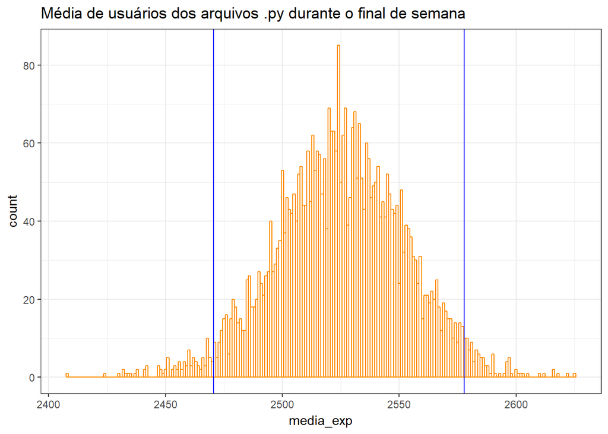

```r
ggplot(experimentos.fim.semana.py, aes(x = media_exp)) +
  geom_histogram(binwidth = 1, colour = "darkorange", fill = "white") +
  geom_vline(aes(xintercept = ci.fim.semana.py[[1]]), colour = "blue") +
  geom_vline(aes(xintercept = ci.fim.semana.py[[2]]), colour = "blue") +
  ggtitle("Média de usuários dos arquivos .py durante o final de semana")
```

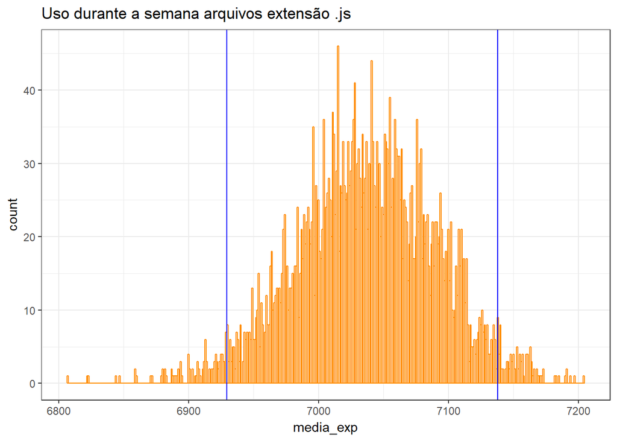

```r
# Java Script

experimentos.semana.js = data_frame(i = 1:repeticoes) %>%
  rowwise() %>%
  mutate(media_exp = exp_com_bootstrap(semana.js$users)) # <- Aqui!


experimentos.fim.semana.js = data_frame(i = 1:repeticoes) %>%
  rowwise() %>%
  mutate(media_exp = exp_com_bootstrap(fim.semana.js$users)) # <- Aqui!

# IC com 95%:
alpha = .05
ci.semana.js = quantile(experimentos.semana.js$media_exp,
              probs = c(alpha/2, 1 - alpha/2))

# IC com 95%:
alpha = .05
ci.fim.semana.js = quantile(experimentos.fim.semana.js$media_exp,
              probs = c(alpha/2, 1 - alpha/2))

ggplot(experimentos.semana.js, aes(x = media_exp)) +
  geom_histogram(binwidth = 1, colour = "darkorange", fill = "white") +
  geom_vline(aes(xintercept = ci.semana.js[[1]]), colour = "blue") +
  geom_vline(aes(xintercept = ci.semana.js[[2]]), colour = "blue") +
  ggtitle("Uso durante a semana arquivos extensão .js")
```

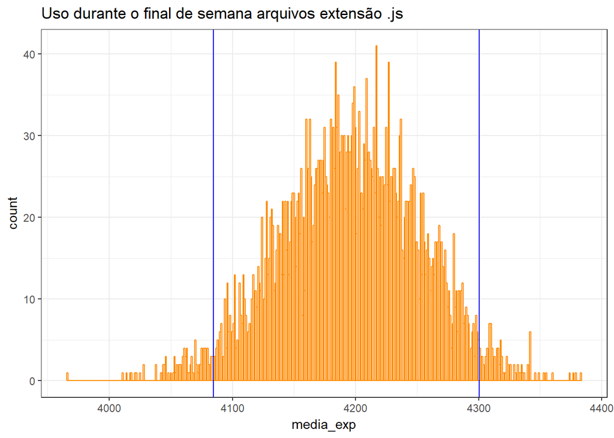

```r
ggplot(experimentos.fim.semana.js, aes(x = media_exp)) +
  geom_histogram(binwidth = 1, colour = "darkorange", fill = "white") +
  geom_vline(aes(xintercept = ci.fim.semana.js[[1]]), colour = "blue") +
  geom_vline(aes(xintercept = ci.fim.semana.js[[2]]), colour = "blue") +
  ggtitle("Uso durante o final de semana arquivos extensão .js")
```

Nestes gráficos estão presentes os Intervalos de Confiança (demarcados pela linha azul), no qual temos confiabilidade de 95% que a média da população esteja presente nesse intervalo, a partir disso podemos chegar as conclusões.

# Pergunta 1: Para cada uma delas, há uma diferença significativa na sua popularidade durante a semana e durante o fim de semana? Essa diferença é grande?

**Python** - Levando em consideração que o intervalo de confiança, para *“A média de usuários dos arquivos .py durante a semana”*(IC1) é **[4591;4710]** já *“A média de usuários dos arquivos .py durante o final de semana”*(IC2) é **[2469;2578]**, temos que IC1 é quase o dobro de IC2, dessa forma podemos inferir que existe uma grande diferença na quantidade de usuários durante a semana para os usuários do final de semana.

# Pergunta 2: Existe uma diferença significativa entre as duas linguagens na sua variação de popularidade nos finais de semana?